# CBS Comscore v Nielsen Primetime Entertainment Comparisons

# Overview

As negotiations between CBS and Nielsen are stalled, CBS is suggesting that they may switch to using ComScore’s TV Essentials as an alternative data source.

This analysis looks at how data produced by ComScore differed from what was produced by Nielsen for primetime in 4Q17.

# Summary

ComScore and Nielsen are most similar in household projection and, to a lesser extent, older viewers. Similarity in households is largely a function of how the ComScore data are collected–through set-top box data.

ComScore’s demographics are actually reported as “HH with…” (e.g. Household with P18-49), indicating that rather than collecting actual demographic viewing data ComScore projects demographics based on household composition

ComScore’s ratings are consistently higher than Nielsen’s, often considerably so.

Disparities between the two systems become increasingly problematic among younger populations.

# Broadcast

| Net | Series | HH | P18.34 | P18.49 | P25.54 | P35.64 | CS_HH | CS_P18.34 | CS_P18.49 | CS_P25.54 | CS_P35.64 |
| --- | --- | --- | --- | --- | --- | --- | --- | --- | --- | --- | --- |
| NBC | This Is Us | 7.88 | 2.39 | 3.50 | 4.31 | 5.78 | 8.55 | 9.04 | 8.94 | 8.87 | 8.86 |
| CBS | Big Bang Theory | 7.36 | 1.47 | 2.59 | 3.73 | 5.79 | 9.00 | 8.56 | 8.61 | 8.76 | 9.38 |
| ABC | Good Doctor | 7.33 | 1.75 | 2.42 | 3.03 | 4.54 | 7.21 | 6.68 | 6.66 | 6.69 | 7.16 |
| ABC | Grey’s Anatomy | 5.64 | 1.93 | 2.36 | 2.75 | 3.47 | 6.93 | 7.35 | 7.23 | 7.14 | 7.02 |
| CBS | Young Sheldon | 7.09 | 1.31 | 2.32 | 3.41 | 5.46 | 7.99 | 7.35 | 7.44 | 7.57 | 8.22 |
| NBC | Voice | 6.04 | 1.26 | 2.04 | 2.78 | 4.53 | 8.00 | 7.68 | 7.57 | 7.66 | 8.24 |
| FOX | Empire | 3.92 | 1.50 | 2.02 | 2.39 | 2.84 | 4.11 | 4.37 | 4.35 | 4.32 | 4.28 |
| ABC | Modern Family | 3.88 | 1.19 | 1.93 | 2.51 | 3.20 | 4.91 | 5.10 | 5.19 | 5.19 | 5.27 |
| FOX | Simpsons | 2.42 | 1.36 | 1.72 | 1.95 | 1.86 | 3.44 | 3.68 | 3.76 | 3.73 | 3.64 |
| CBS | Survivor: Heroes vs. Healers vs. Hustlers | 4.74 | 1.13 | 1.71 | 2.34 | 3.60 | 6.09 | 5.65 | 5.82 | 5.93 | 6.37 |
| ABC | Scandal | 4.10 | 1.11 | 1.58 | 1.95 | 2.60 | 4.91 | 4.90 | 4.89 | 4.87 | 4.93 |
| CBS | Mom | 5.36 | 0.86 | 1.58 | 2.43 | 4.16 | 6.31 | 5.72 | 5.78 | 5.93 | 6.55 |
| ABC | Goldbergs | 3.29 | 0.79 | 1.54 | 2.04 | 2.66 | 4.45 | 4.33 | 4.59 | 4.61 | 4.78 |
| FOX | Family Guy | 2.01 | 1.34 | 1.52 | 1.66 | 1.42 | 2.70 | 2.97 | 3.03 | 3.00 | 2.86 |
| NBC | Chicago P.D. | 4.80 | 0.95 | 1.49 | 1.94 | 3.02 | 5.71 | 5.22 | 5.27 | 5.31 | 5.65 |
| ABC | How to Get Away with Murder | 3.38 | 1.10 | 1.45 | 1.76 | 2.21 | 3.92 | 4.01 | 3.98 | 3.96 | 3.98 |
| CBS | Criminal Minds | 4.71 | 0.85 | 1.45 | 2.02 | 3.22 | 5.63 | 5.13 | 5.21 | 5.29 | 5.73 |
| ABC | Middle | 3.61 | 0.84 | 1.44 | 1.96 | 2.72 | 4.78 | 4.63 | 4.72 | 4.76 | 5.07 |
| NBC | Law & Order: Special Victims Unit | 4.04 | 0.94 | 1.42 | 1.82 | 2.52 | 4.96 | 4.61 | 4.66 | 4.68 | 4.88 |
| NBC | Good Place | 2.89 | 0.92 | 1.41 | 1.76 | 2.20 | 3.63 | 3.56 | 3.66 | 3.68 | 3.78 |
| ABC | American Housewife | 3.10 | 0.76 | 1.39 | 1.88 | 2.52 | 4.06 | 4.11 | 4.22 | 4.23 | 4.35 |
| CBS | NCIS | 7.28 | 0.78 | 1.39 | 2.15 | 4.28 | 8.09 | 6.63 | 6.73 | 6.85 | 7.78 |
| NBC | Chicago Fire | 4.50 | 0.84 | 1.39 | 1.83 | 2.94 | 5.37 | 4.93 | 4.99 | 5.03 | 5.37 |
| FOX | Star | 2.76 | 1.04 | 1.38 | 1.64 | 1.99 | 2.70 | 2.82 | 2.82 | 2.82 | 2.84 |
| ABC | black-ish | 2.85 | 0.81 | 1.35 | 1.76 | 2.19 | 3.63 | 3.60 | 3.75 | 3.77 | 3.89 |
| CBS | Life in Pieces | 4.25 | 0.73 | 1.33 | 1.96 | 3.29 | 5.16 | 4.84 | 4.87 | 4.95 | 5.40 |
| ABC | Dancing With Stars | 5.72 | 0.93 | 1.32 | 1.80 | 3.09 | 6.51 | 5.56 | 5.58 | 5.64 | 6.18 |
| NBC | Chicago Med | 4.54 | 0.77 | 1.31 | 1.76 | 3.00 | 5.56 | 5.14 | 5.13 | 5.18 | 5.57 |
| FOX | Ghosted | 1.98 | 0.98 | 1.30 | 1.53 | 1.55 | 2.70 | 2.78 | 2.86 | 2.87 | 2.87 |
| CBS | Bull | 6.47 | 0.75 | 1.28 | 2.01 | 3.86 | 6.61 | 5.53 | 5.59 | 5.68 | 6.40 |

[output cut: 60 more lines]

## By Program Average

The numbers for demographic comparisons are more concerning, especially in the younger ranges.

**Broadcast Program Summary Table**

| Demo | Correlation | Avg % Diff | Max Diff |
| --- | --- | --- | --- |
| HH | 0.97 | 22% | 53% |
| 18.34 | 0.69 | 432% | 914% |
| 18.49 | 0.83 | 227% | 512% |
| 25.54 | 0.90 | 145% | 320% |
| 35.64 | 0.97 | 80% | 150% |

**Broadcast Program Correlation Plots: Nielsen vs. ComScore**

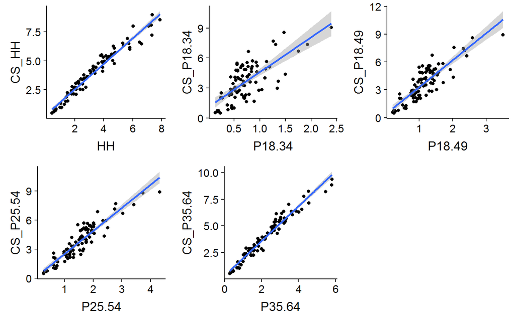

## Broadcast Programs by Network

Breaking down the percent differences by network reveals one likely reason that CBS might be promoting ComScore–it benefits far more than any other broadcast network if the industry were to move that way, especially among younger demos.

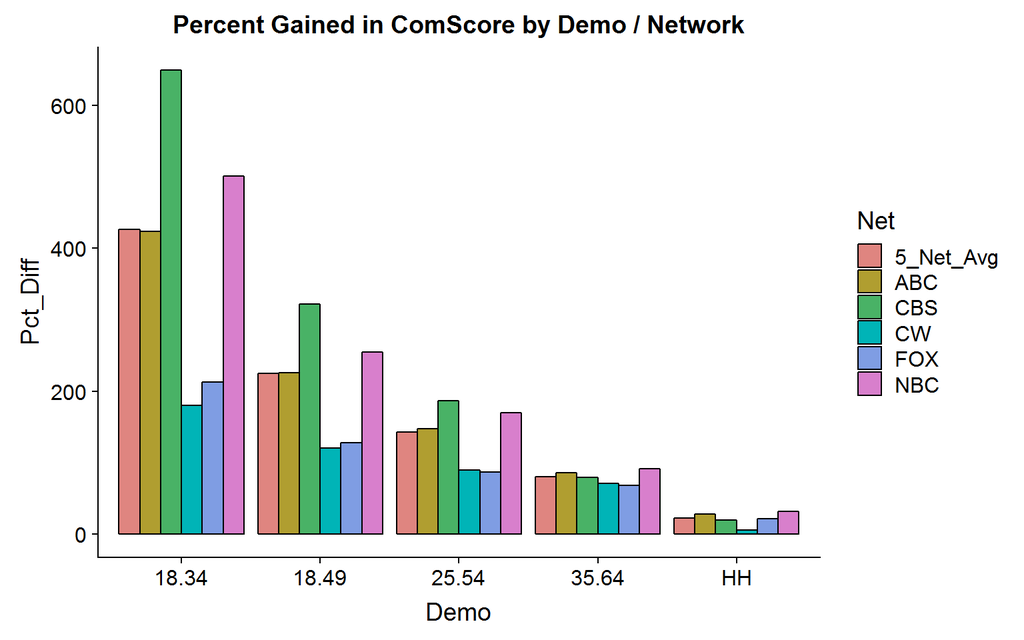

**Broadcast Network % Change (Nielsen to ComScore) Summary Table**

| Demo | ABC | CBS | CW | FOX | NBC | 5-Net Avg |
| --- | --- | --- | --- | --- | --- | --- |
| HH | 28% | 20% | 6% | 21% | 32% | 22% |
| 18.34 | 424% | 649% | 180% | 213% | 501% | 426% |
| 18.49 | 226% | 322% | 120% | 128% | 255% | 225% |
| 25.54 | 147% | 187% | 90% | 87% | 170% | 143% |
| 35.64 | 86% | 79% | 71% | 68% | 91% | 80% |

## By Program Genre

In addition to seeing how broadcast programs perform on average we can look at whether any genres are more impacted than others.

Sci-Fi / Fantasy programming consistently has much lower correlation between the two systems, particularly among P18-34 where correlation is 0.28. Other genres and older demos are more aligned between the two.

**Broadcast Program Genre Correlation Summary Table**

| Demo | Comedy | Drama | SF/F | Reality |
| --- | --- | --- | --- | --- |
| HH | 0.99 | 0.97 | 0.94 | 0.99 |
| 18.34 | 0.64 | 0.70 | 0.28 | 0.97 |
| 18.49 | 0.88 | 0.83 | 0.74 | 0.98 |
| 25.54 | 0.96 | 0.90 | 0.85 | 0.98 |
| 35.64 | 0.98 | 0.96 | 0.93 | 0.99 |

The low correlation between sources for Sci-Fi / Fantasy is to the genre’s relative detriment. While it sees some gains in ComScore they are not nearly as strong as those seen for the other genres. Dramas, for example, are typically credited with gains nearly twice the rate of SF/F.

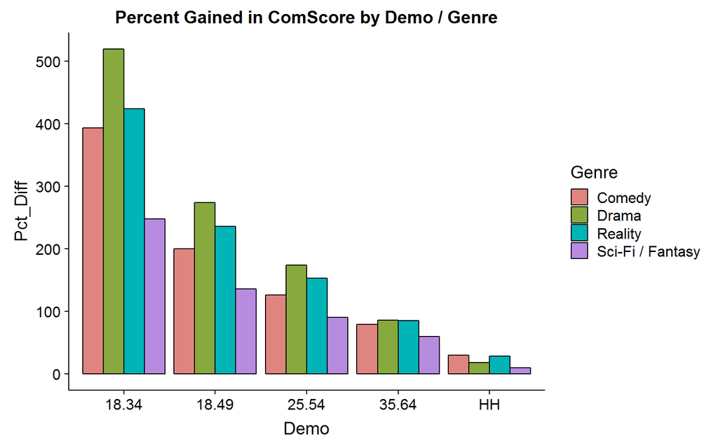

# Cable

| Net | HH | P18.34 | P18.49 | P25.54 | P35.64 | CS_HH | CS_P18.34 | CS_P18.49 | CS_P25.54 | CS_P35.64 |
| --- | --- | --- | --- | --- | --- | --- | --- | --- | --- | --- |
| ESPN | 1.74 | 0.88 | 0.99 | 1.09 | 1.18 | 1.99 | 2.07 | 2.08 | 2.07 | 2.07 |
| TBS | 0.93 | 0.37 | 0.50 | 0.61 | 0.72 | 0.94 | 0.96 | 0.97 | 0.98 | 0.99 |
| USA | 0.82 | 0.33 | 0.41 | 0.48 | 0.55 | 0.79 | 0.80 | 0.81 | 0.81 | 0.81 |
| FREEFORM | 0.53 | 0.37 | 0.39 | 0.40 | 0.36 | 0.52 | 0.62 | 0.61 | 0.59 | 0.55 |
| HALL | 1.22 | 0.21 | 0.33 | 0.45 | 0.72 | 1.19 | 1.05 | 1.05 | 1.06 | 1.16 |
| TNT | 0.60 | 0.30 | 0.33 | 0.36 | 0.40 | 0.66 | 0.65 | 0.66 | 0.66 | 0.68 |
| AMC | 0.52 | 0.22 | 0.31 | 0.37 | 0.42 | 0.59 | 0.63 | 0.63 | 0.63 | 0.62 |
| FX | 0.46 | 0.27 | 0.30 | 0.33 | 0.32 | 0.50 | 0.56 | 0.55 | 0.55 | 0.53 |
| DSC | 0.67 | 0.18 | 0.29 | 0.38 | 0.51 | 0.72 | 0.70 | 0.71 | 0.72 | 0.75 |
| A&E | 0.55 | 0.19 | 0.27 | 0.35 | 0.42 | 0.51 | 0.49 | 0.50 | 0.51 | 0.53 |
| FOOD | 0.54 | 0.20 | 0.27 | 0.32 | 0.39 | 0.57 | 0.57 | 0.58 | 0.58 | 0.60 |
| BRAVO | 0.48 | 0.19 | 0.26 | 0.32 | 0.35 | 0.70 | 0.76 | 0.77 | 0.77 | 0.74 |
| HST | 0.68 | 0.14 | 0.25 | 0.34 | 0.50 | 0.68 | 0.62 | 0.64 | 0.65 | 0.70 |
| HGTV | 0.77 | 0.16 | 0.24 | 0.31 | 0.47 | 0.78 | 0.73 | 0.73 | 0.74 | 0.79 |
| ID | 0.67 | 0.13 | 0.23 | 0.32 | 0.46 | 0.60 | 0.51 | 0.53 | 0.54 | 0.60 |
| VH1 | 0.31 | 0.23 | 0.23 | 0.23 | 0.18 | 0.44 | 0.52 | 0.51 | 0.49 | 0.45 |
| MTV | 0.27 | 0.25 | 0.22 | 0.20 | 0.14 | 0.36 | 0.48 | 0.44 | 0.43 | 0.36 |
| FOXSP1 | 0.43 | 0.16 | 0.21 | 0.25 | 0.31 | 0.54 | 0.53 | 0.53 | 0.53 | 0.55 |
| COM | 0.24 | 0.21 | 0.20 | 0.19 | 0.15 | 0.24 | 0.28 | 0.28 | 0.27 | 0.25 |
| FNC | 1.36 | 0.09 | 0.20 | 0.33 | 0.69 | 1.39 | 1.05 | 1.06 | 1.10 | 1.27 |
| NFLNET | 0.37 | 0.16 | 0.20 | 0.24 | 0.27 | 0.42 | 0.45 | 0.45 | 0.45 | 0.45 |
| TLC | 0.52 | 0.15 | 0.20 | 0.24 | 0.32 | 0.54 | 0.54 | 0.54 | 0.54 | 0.55 |
| CNN | 0.56 | 0.09 | 0.18 | 0.24 | 0.35 | 0.70 | 0.61 | 0.62 | 0.63 | 0.69 |
| MSNBC | 1.06 | 0.08 | 0.18 | 0.27 | 0.50 | 0.98 | 0.70 | 0.73 | 0.74 | 0.88 |
| BET | 0.29 | 0.15 | 0.17 | 0.18 | 0.18 | 0.35 | 0.38 | 0.38 | 0.37 | 0.36 |
| LIFE | 0.41 | 0.12 | 0.17 | 0.21 | 0.27 | 0.50 | 0.50 | 0.50 | 0.50 | 0.52 |
| E! | 0.23 | 0.15 | 0.15 | 0.16 | 0.14 | 0.31 | 0.36 | 0.35 | 0.35 | 0.32 |
| PARAM | 0.22 | 0.11 | 0.14 | 0.16 | 0.17 | 0.25 | 0.27 | 0.27 | 0.27 | 0.27 |
| SYFY | 0.29 | 0.10 | 0.14 | 0.17 | 0.22 | 0.29 | 0.29 | 0.29 | 0.30 | 0.31 |
| truTV | 0.18 | 0.14 | 0.14 | 0.13 | 0.11 | 0.27 | 0.31 | 0.32 | 0.31 | 0.28 |
| FXX | 0.19 | 0.12 | 0.13 | 0.14 | 0.13 | 0.20 | 0.23 | 0.23 | 0.22 | 0.21 |
| NICKJR | 0.34 | 0.12 | 0.12 | 0.12 | 0.09 | 0.38 | 0.51 | 0.48 | 0.45 | 0.37 |
| TRAVEL | 0.27 | 0.07 | 0.12 | 0.16 | 0.21 | 0.31 | 0.30 | 0.31 | 0.31 | 0.33 |
| TVLD | 0.43 | 0.06 | 0.11 | 0.17 | 0.29 | 0.52 | 0.45 | 0.45 | 0.47 | 0.52 |
| APL | 0.29 | 0.07 | 0.10 | 0.13 | 0.18 | 0.26 | 0.23 | 0.24 | 0.24 | 0.26 |
| HALLMM | 0.56 | 0.06 | 0.10 | 0.15 | 0.30 | 0.86 | 0.68 | 0.69 | 0.70 | 0.80 |
| LMN | 0.25 | 0.07 | 0.10 | 0.13 | 0.17 | 0.30 | 0.29 | 0.29 | 0.29 | 0.31 |
| CNBC | 0.19 | 0.08 | 0.09 | 0.11 | 0.11 | 0.25 | 0.24 | 0.24 | 0.24 | 0.24 |
| ESPN2 | 0.17 | 0.07 | 0.09 | 0.10 | 0.11 | 0.31 | 0.31 | 0.31 | 0.31 | 0.32 |
| OWN | 0.27 | 0.05 | 0.09 | 0.12 | 0.18 | 0.47 | 0.45 | 0.46 | 0.46 | 0.49 |
| WeTV | 0.24 | 0.06 | 0.09 | 0.12 | 0.16 | 0.18 | 0.17 | 0.17 | 0.18 | 0.18 |
| NGC | 0.23 | 0.05 | 0.08 | 0.11 | 0.16 | 0.27 | 0.24 | 0.25 | 0.25 | 0.27 |
| CMT | 0.13 | 0.05 | 0.07 | 0.08 | 0.10 | 0.16 | 0.17 | 0.17 | 0.17 | 0.17 |
| GALA | 0.09 | 0.07 | 0.07 | 0.08 | 0.06 | 0.10 | 0.15 | 0.13 | 0.12 | 0.10 |
| SCIENCE | 0.17 | 0.04 | 0.07 | 0.09 | 0.12 | 0.16 | 0.15 | 0.15 | 0.16 | 0.17 |
| WGN | 0.22 | 0.05 | 0.07 | 0.10 | 0.15 | 0.31 | 0.26 | 0.27 | 0.27 | 0.30 |
| GSN | 0.23 | 0.05 | 0.06 | 0.07 | 0.10 | 0.38 | 0.32 | 0.33 | 0.33 | 0.36 |
| HLN | 0.19 | 0.03 | 0.06 | 0.07 | 0.11 | 0.20 | 0.16 | 0.17 | 0.17 | 0.19 |
| IFC | 0.10 | 0.04 | 0.06 | 0.07 | 0.08 | 0.12 | 0.12 | 0.12 | 0.12 | 0.12 |
| OXGN | 0.19 | 0.03 | 0.06 | 0.08 | 0.13 | 0.20 | 0.17 | 0.18 | 0.18 | 0.20 |
| BBCA | 0.13 | 0.03 | 0.05 | 0.07 | 0.10 | 0.12 | 0.11 | 0.12 | 0.12 | 0.13 |
| NKTN | 0.14 | 0.05 | 0.05 | 0.04 | 0.04 | 0.22 | 0.26 | 0.27 | 0.26 | 0.23 |
| COOKING | 0.08 | 0.02 | 0.04 | 0.05 | 0.06 | 0.11 | 0.11 | 0.11 | 0.11 | 0.12 |
| DISNEYXD | 0.10 | 0.03 | 0.04 | 0.04 | 0.03 | 0.14 | 0.16 | 0.17 | 0.16 | 0.14 |
| DIY | 0.14 | 0.02 | 0.04 | 0.05 | 0.09 | 0.15 | 0.14 | 0.14 | 0.15 | 0.16 |
| FOXDEPORTE | 0.06 | 0.03 | 0.04 | 0.05 | 0.04 | 0.06 | 0.09 | 0.08 | 0.08 | 0.07 |
| MTV2 | 0.06 | 0.05 | 0.04 | 0.04 | 0.03 | 0.10 | 0.11 | 0.11 | 0.11 | 0.10 |
| NBCSN | 0.10 | 0.04 | 0.04 | 0.05 | 0.07 | 0.17 | 0.16 | 0.16 | 0.16 | 0.17 |
| TVONE | 0.10 | 0.02 | 0.04 | 0.06 | 0.07 | 0.17 | 0.17 | 0.18 | 0.18 | 0.18 |
| VICE | 0.06 | 0.03 | 0.04 | 0.05 | 0.04 | 0.08 | 0.09 | 0.09 | 0.09 | 0.09 |
| BOOM | 0.06 | 0.02 | 0.03 | 0.03 | 0.02 | 0.12 | 0.15 | 0.15 | 0.15 | 0.13 |
| DFC | 0.06 | 0.03 | 0.03 | 0.03 | 0.03 | 0.07 | 0.08 | 0.08 | 0.08 | 0.07 |
| FYI | 0.07 | 0.02 | 0.03 | 0.04 | 0.05 | 0.09 | 0.09 | 0.09 | 0.09 | 0.10 |
| Pop | 0.08 | 0.02 | 0.03 | 0.04 | 0.06 | 0.12 | 0.11 | 0.11 | 0.11 | 0.13 |
| TEENNCK | 0.09 | 0.03 | 0.03 | 0.03 | 0.02 | 0.13 | 0.15 | 0.16 | 0.16 | 0.14 |
| UPTV | 0.07 | 0.02 | 0.03 | 0.03 | 0.05 | 0.12 | 0.11 | 0.11 | 0.11 | 0.12 |
| AHC | 0.10 | 0.01 | 0.02 | 0.03 | 0.06 | 0.15 | 0.12 | 0.13 | 0.13 | 0.15 |
| BETHER | 0.03 | 0.01 | 0.02 | 0.02 | 0.02 | 0.05 | 0.06 | 0.06 | 0.06 | 0.06 |
| ESPNU | 0.04 | 0.01 | 0.02 | 0.02 | 0.03 | 0.09 | 0.09 | 0.09 | 0.09 | 0.09 |
| FUSE | 0.03 | 0.01 | 0.02 | 0.02 | 0.02 | 0.03 | 0.04 | 0.04 | 0.04 | 0.03 |
| LOGO | 0.04 | 0.01 | 0.02 | 0.02 | 0.03 | 0.05 | 0.05 | 0.06 | 0.06 | 0.06 |
| WEATH | 0.11 | 0.02 | 0.02 | 0.04 | 0.06 | 0.12 | 0.09 | 0.10 | 0.10 | 0.12 |
| CHILL | 0.02 | 0.00 | 0.01 | 0.01 | 0.01 | 0.05 | 0.04 | 0.04 | 0.05 | 0.05 |
| GAC | 0.05 | 0.01 | 0.01 | 0.02 | 0.04 | 0.05 | 0.05 | 0.05 | 0.05 | 0.06 |
| GOLF | 0.05 | 0.01 | 0.01 | 0.02 | 0.03 | 0.09 | 0.08 | 0.08 | 0.08 | 0.09 |
| UNIKIDS | 0.03 | 0.01 | 0.01 | 0.01 | 0.01 | 0.03 | 0.04 | 0.04 | 0.04 | 0.03 |

## Cable Average

*Because ESPN’s performance is a strong outlier, posting nearly double the P18-49 rating as its nearest competitor in both data sets, it will be excluded from the rest of the analysis.*

Correlations between the two sources among cable networks were fairly tight with differences among younger viewers larger than those among households and older viewers.

**Cable Network Correlation Plots**

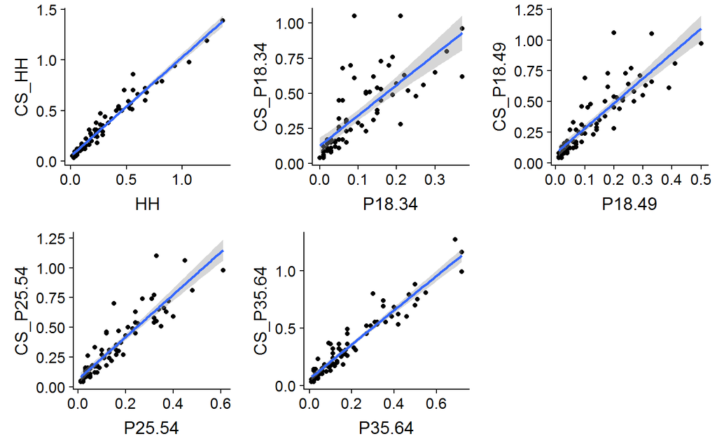

**Cable Network Summary Table**

| Demo | Correlation | Avg % Diff | Max Diff |
| --- | --- | --- | --- |
| HH | 0.98 | 27% | 212% |
| 18.34 | 0.86 | 363% | 1627% |
| 18.49 | 0.92 | 222% | 777% |
| 25.54 | 0.95 | 163% | 519% |
| 35.64 | 0.97 | 124% | 551% |

## Cable Network Quintiles

Because there are so many networks that have such a range of ratings it is important to look at them with more detail. Breaking the networks down into quintiles, 5 groups of 15 networks each in descending order of Nielsen P18-49 ratings, allows us to see how the impact differs by the size of the networks. We can see below that as the networks get smaller the viewing reported in ComScore gets increasingly higher.

[figure not shown]

**Cable by Quintile Correlation Table**

| Demo | All Nets | Quint 1 | Quint 2 | Quint 3 | Quint 4 | Quint 5 |
| --- | --- | --- | --- | --- | --- | --- |
| HH | 0.98 | 0.95 | 0.99 | 0.92 | 0.87 | 0.89 |
| 18.34 | 0.86 | 0.33 | -0.34 | 0.26 | 0.52 | 0.70 |
| 18.49 | 0.92 | 0.60 | 0.54 | 0.59 | 0.44 | 0.74 |
| 25.54 | 0.95 | 0.75 | 0.93 | 0.67 | 0.29 | 0.66 |
| 35.64 | 0.97 | 0.90 | 0.98 | 0.81 | 0.46 | 0.57 |

### 1st Quintile

Among the top 15 networks, which range from 0.23 to 0.50, households have a reasonable correlation between sources (0.95) but the older demos aren’t strong: P25-54 0.75 and P35-64 0.90.

Younger demos are nowhere near acceptable: P18-34 0.33 and P18-49 0.60.

**Quintile 1 Cable Network Correlation Plots**

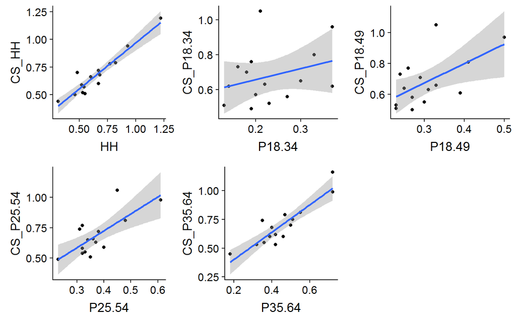

### 2nd Quintile

In the 2nd Quintile HH and P35-64 are both well correlated (0.99 and 0.98) and P25-54 is okay (0.93) but P18-49 is only 0.54 and P18-34 is -0.34 (negative correlation indicates direction, not strength).

**Quintile 2 Cable Network Correlation Plots**

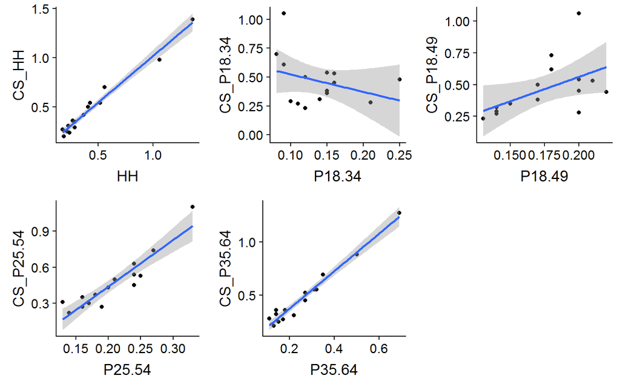

### 3rd Quintile

Household correlation for networks in the 3rd Quintile is 0.92, P35-64 drops to below 0.9 for the first time (0.81) and P18-34 is at its lowest of all the quintiles (0.26).

**Quintile 3 Cable Network Correlation Plots**

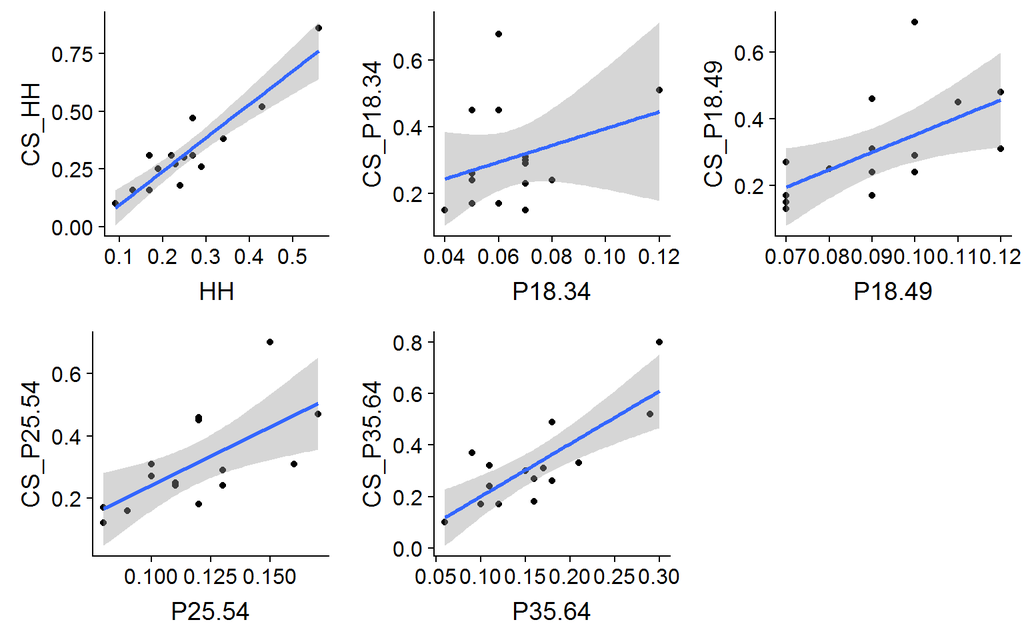

### 4th Quintile

Correlations in the 4th Quintile are at their lowest for Households (0.87), P18-49 (0.44), P25-54 (0.29), and P35-64 (0.46).

**Quintile 4 Cable Network Correlation Plots**

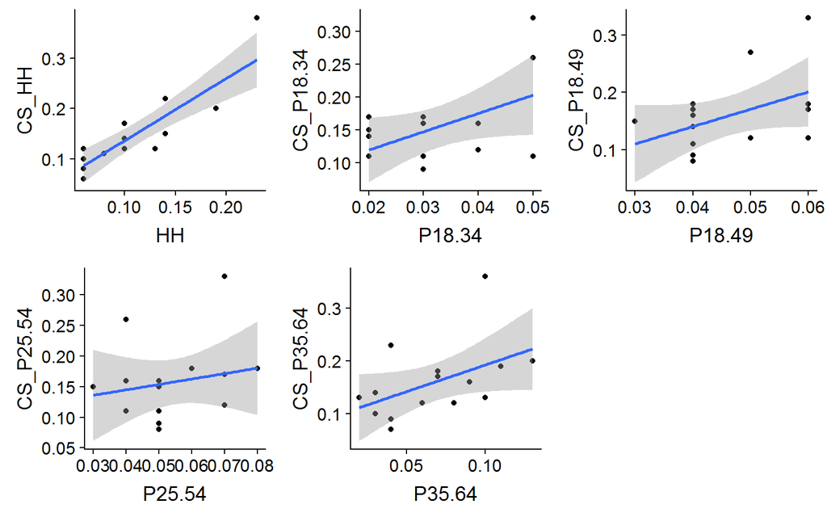

### 5th Quintile

As the average network ratings approach zero, correlations improve across the board, though none are strong.

**Quintile 5 Cable Network Correlation Plots**

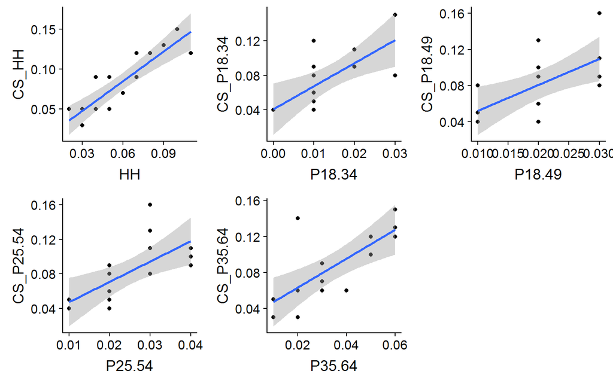

## Cable by Network Type

As there were notable differences in program genres in broadcast, cable networks were broken down by general type.

This analysis reveals that P18-34 gains outstrip those for any other demos in a move to ComScore, particularly among news networks.

Kids networks had the most to gain among any on cable, followed by sports networks. General entertainment networks would see the least amount of movement.

Correlations tended to be strongest among network types with fewer members: kids, news, and sports.

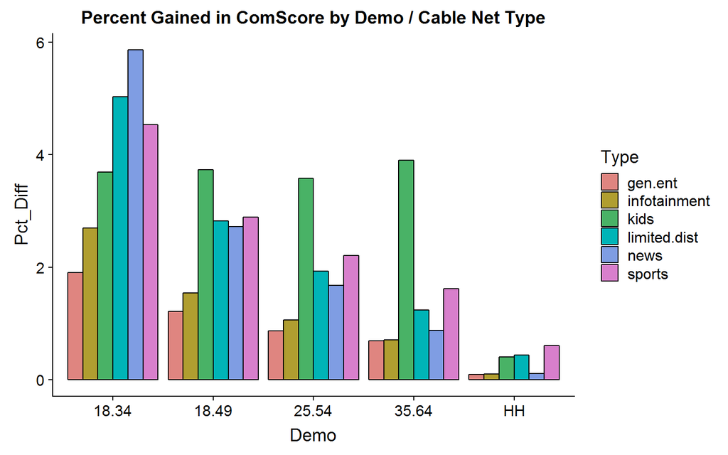

**Cable by Network Type Correlation Table**

| Demo | Gen.Ent | Infotain | Kids | Lim.Dist | News | Sports |
| --- | --- | --- | --- | --- | --- | --- |
| HH | 0.97 | 0.98 | 0.98 | 0.98 | 0.99 | 0.98 |
| 18.34 | 0.72 | 0.79 | 0.99 | 0.68 | 0.79 | 0.99 |
| 18.49 | 0.86 | 0.95 | 0.97 | 0.83 | 0.95 | 0.98 |
| 25.54 | 0.92 | 0.96 | 0.95 | 0.87 | 0.99 | 0.98 |
| 35.64 | 0.95 | 0.96 | 0.91 | 0.95 | 1.00 | 0.98 |

### General Entertainment Cable Networks

General Entertainment networks have a similar correlation as the full cable average, just a bit lower overall.

**General Entertainment Cable Network Correlation Plots**

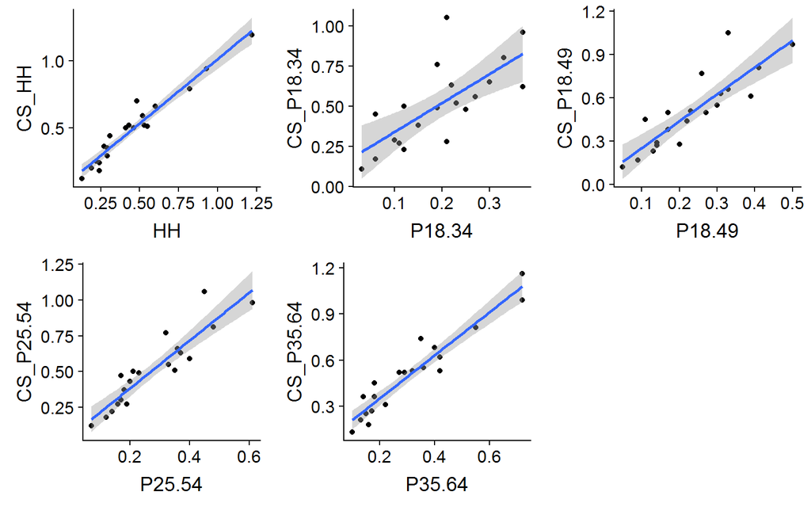

### Infotainment Cable Networks

Infotainment correlation was as strong or stronger than the cable average except among P18-34 where it is a little lower.

**Infotainment Cable Network Correlation Plots**

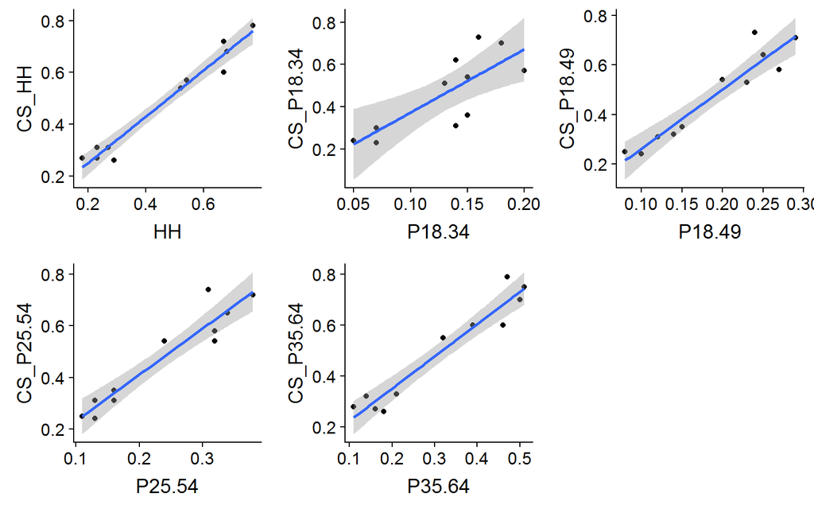

### Kids Cable Networks

P18-34 correlation is stronger than any other network among kids networks (0.99). As mentioned above, fewer networks in this class promote greater correlation.

**Kids Cable Network Correlation Plots**

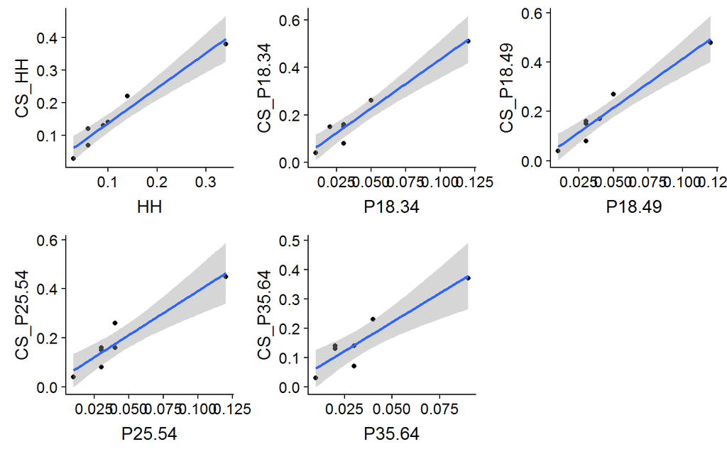

### Limited Distribution Cable Networks

Limited Distribution networks have the lowest correlation of all network types for P18-34 (0.68), P18-49 (0.83), and P25-54 (0.87).

**Limited Distribution Cable Network Correlation Plots**

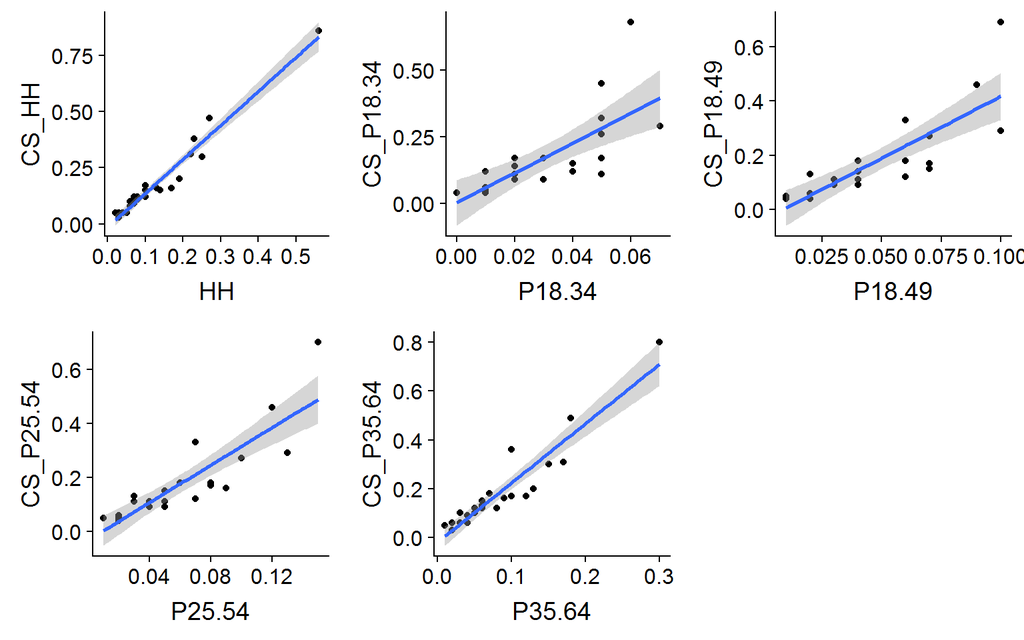

### Cable News Networks

News network correlations are very high, though the graph for P18-34 below shows the variability that goes into this number, especially given the small number of members of this class.

**Cable News Network Correlation Plots**

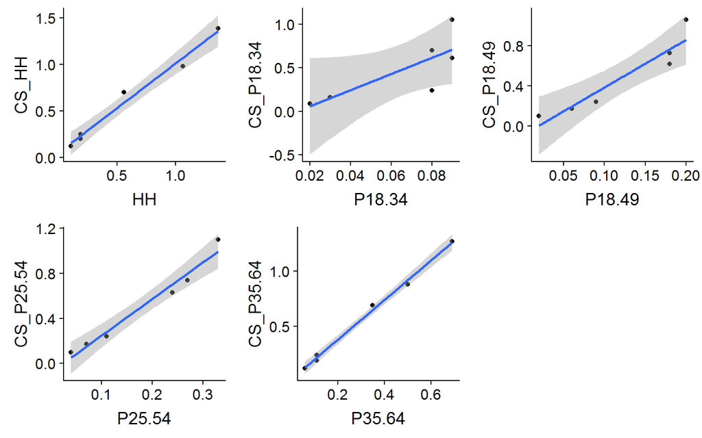

### Cable Sports Networks

Sports networks have strong correlations between the sources, but this is a function of the low number of members in this class.

**Cable Sports Network Correlation Plots**

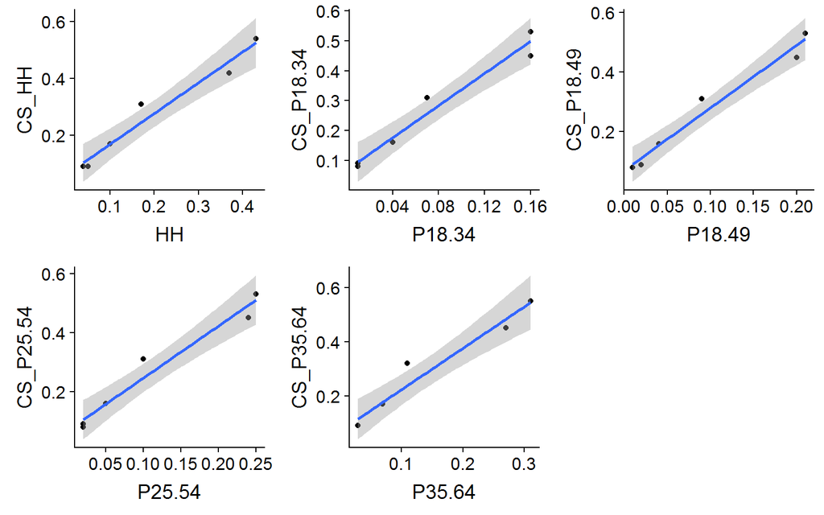

AJ Bentley

January 3, 2019